# Regressão Linear para Explicar a votação de Deputados

Lucas Lima Vieira

## Descrição dos Dados

Os dados podem ser baixados nos links a seguir: [Eleições 2006](https://canvas.instructure.com/courses/1402758/files/69433650/download?verifier=GvsTSXgoNVf22qbJerOSPAkHsOsdBUZD1Z1AD4lI), [Eleições 2010](https://canvas.instructure.com/courses/1402758/files/69433651/download?verifier=ZETCucixF9Mkjhfp7CLuchjRXWlSwtw69ZhQ0jyk), [Eleições 2006 + 2010](https://canvas.instructure.com/courses/1402758/files/69406530/download?verifier=w88G2kvz56ZJbCSGXgm22zKizUdptatpCDigS9ei&wrap=1).

- “sequencial_candidato”: (character) id do candidato.
- “nome”: (character)
- “uf”: (character)
- “partido”: (character)
- “quantidade_doacoes”: (integer)
- “quantidade_doadores”: (integer) número de doadores diferentes.
- “total_receita”: (double) soma em R$ das doações.
- “media_receita”: (double) média das doações.
- “recursos_de_outros_candidatos/comites”: (double) quantia em R$ das doações provenientes de outros candidatos ou comite partidário.
- “recursos_de_pessoas_fisicas”: (double) quantia em R$ das doações provenientes de outros CPFs.
- “recursos_de_pessoas_juridicas”: (double) quantia em R$ das doações provenientes de outros CNPJ.
- “recursos_proprios”: (double) quantia em R$ das doações provenientes do próprio candidato.
- “recursos_de_partido_politico”: (double) quantia em R$ das doações provenientes do partido político do candidato.
- “votos”: (integer) variável alvo. Se refere ao número de votos na campanha de 2006 e 2010.
- “quantidade_despesas”: (integer)
- “quantidade_fornecedores”: (integer) número de fornecedores/despesas diferentes.
- “total_despesa”: (double) soma em R$ das despesas de campanha.
- “media_despesa”: (double) média das despesas de campanha.
- “cargo”: (character)
- “Sexo”: (character)
- “grau”: (character) grau de instrução do candidato.
- “estado_civil”: (character)
- “ocupacao”: (character) ocupação do candidato.

## Transformando variáveis categóricas em variáveis numéricas

```r
eleicoes_2006 %>%
  mutate(uf = as.factor(uf),
         nome = as.factor(nome),
         sexo = as.factor(sexo),
         grau = as.factor(grau),
         nome = as.factor(nome),
         cargo = as.factor(cargo),
         partido = as.factor(partido),
         ocupacao = as.factor(ocupacao),
         estado_civil = as.factor(estado_civil),
         sequencial_candidato = as.numeric(sequencial_candidato)) -> eleicoes_2006
```

```r
eleicoes_2010 %>%
  mutate(uf = as.factor(uf),
         nome = as.factor(nome),
         sexo = as.factor(sexo),
         grau = as.factor(grau),
         nome = as.factor(nome),
         cargo = as.factor(cargo),
         partido = as.factor(partido),
         ocupacao = as.factor(ocupacao),
         estado_civil = as.factor(estado_civil),
         sequencial_candidato = as.numeric(sequencial_candidato)) -> eleicoes_2010
```

```r
eleicoes_2006_2010 %>%
  mutate(uf = as.factor(uf),
         nome = as.factor(nome),
         sexo = as.factor(sexo),
         grau = as.factor(grau),
         nome = as.factor(nome),
         cargo = as.factor(cargo),
         partido = as.factor(partido),
         ocupacao = as.factor(ocupacao),
         estado_civil = as.factor(estado_civil),
         sequencial_candidato = as.numeric(sequencial_candidato)) -> eleicoes_2006_2010
```

## Filtrando os dados

```r
dados_filtrados_2006 <- eleicoes_2006 %>% select(-nome, -ano, -cargo)
dados_filtrados_2010 <- eleicoes_2010 %>% select(-nome, -ano, -cargo)
dados_filtrados_2006_2010 <- eleicoes_2006_2010 %>% select(-nome, -ano, -cargo)
```

## Um modelo de regressão múltipla com todas as variáveis é plausível para explicar a variação em y (número de votos) em 2006? Mesma pergunta para 2010.

Um modelo de regressão linear multipla com todas as variáveis não é tão bom para explicar a variação de Y (quantidade de votos), pois analizando as regressões criadas com os dados de 2006 e 2010, podemos observar que os valores de R² e R² ajustato não são tão altos, o que mostra que usar todas as variáveis não é plausível para explicar a variável alvo. Muitas variáveis não são necessárias no modelo, tais como, o cargo que é o mesmo todos os deputados e os nomes dos mesmos.

```r
fit_2006 <- lm(votos ~ ., data=dados_filtrados_2006)
glance(fit_2006)
```

|  | r.squared | adj.r.squared | sigma | statistic | p.value | df | logLik | AIC | BIC | deviance | df.residual |
| --- | --- | --- | --- | --- | --- | --- | --- | --- | --- | --- | --- |
| 1 | 0.5778748 | 0.5487083 | 30549.11 | 19.813 | 0 | 223 | -40244.07 | 80936.15 | 82311.97 | 2.998525e+12 | 3213 |

```r
fit_2010 <- lm(votos ~ ., data=dados_filtrados_2010)
glance(fit_2010)
```

|  | r.squared | adj.r.squared | sigma | statistic | p.value | df | logLik | AIC | BIC | deviance | df.residual |
| --- | --- | --- | --- | --- | --- | --- | --- | --- | --- | --- | --- |
| 1 | 0.5405282 | 0.5129117 | 34587.33 | 19.57262 | 0 | 230 | -47837.13 | 96136.26 | 97592.48 | 4.557839e+12 | 3810 |

## Compare as regressões construídas para 2006 e 2010. Quais as diferenças/semelhanças percebidas? Algumas sugestões:

### Analise os plots de resíduos e verifique se há tendências nos erros para cada ano.

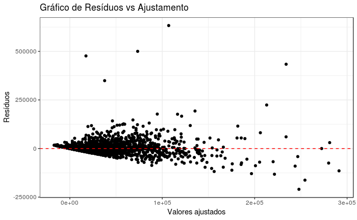

```r
grafico_2006 <- ggplot(fit_2006, aes(.fitted, .resid)) +
  geom_point() + geom_hline(yintercept=0, col="red", linetype="dashed") +
  xlab("Valores ajustados") + ylab("Resíduos") +
  ggtitle("Gráfico de Resíduos vs Ajustamento") + theme_bw()
grafico_2006
```

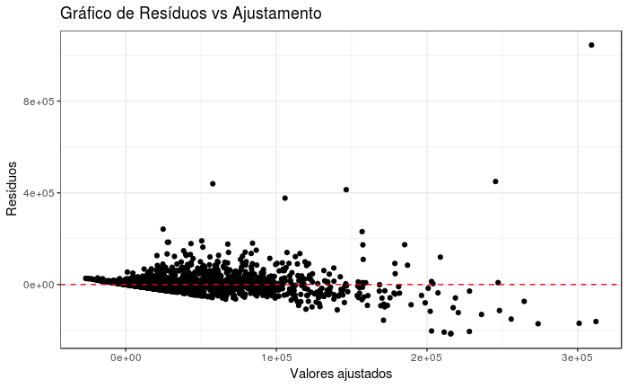

```r
grafico_2010 <- ggplot(fit_2010, aes(.fitted, .resid)) +
  geom_point() + geom_hline(yintercept=0, col="red", linetype="dashed") +
  xlab("Valores ajustados") + ylab("Resíduos") +
  ggtitle("Gráfico de Resíduos vs Ajustamento") + theme_bw()
grafico_2010
```

Em ambos os gráficos, os resíduos não parecem estar dispersos de forma aleatória e simétrica em torno da linha potilhada, isso pode ser um mal sinal para o modelo, indicando que o mesmo não conseguiu explicar bem os erros nos dados.

### Quais variáveis conseguem explicar melhor o número de votos? Compare essas variáveis entre os modelos. Mesma coisa para as variáveis menos explicativas.

Foram utilizada apenas as variáveis numéricas, já que existem muitas categorias nas variáveis catégoricas.

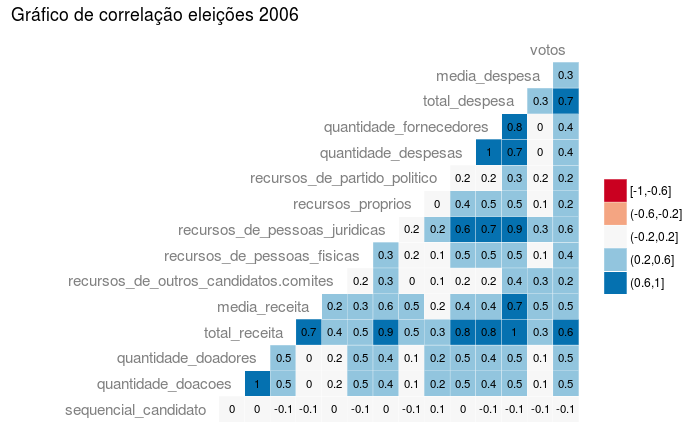

```r
eleicoes_2006 %>%
  select(-partido,
         -uf,-nome,
         -estado_civil,
         -ocupacao,-ano,
         -cargo,-grau,-sexo) %>%
  na.omit() %>%
  ggcorr(palette = "RdBu",
         color = "grey50",
         label = TRUE, hjust = 1,
         label_size = 3, size = 4,
         nbreaks = 5, layout.exp = 7) +
  ggtitle("Gráfico de correlação eleições 2006")
```

[figure not shown]

```r
eleicoes_2010 %>%
  select(-partido,
         -uf,-nome,
         -estado_civil,
         -ocupacao,-ano,
         -cargo,-grau,-sexo) %>%
  na.omit() %>%
  ggcorr(palette = "RdBu",
         color = "grey50",
         label = TRUE, hjust = 1,
         label_size = 3, size = 4,
         nbreaks = 5, layout.exp = 7) +
  ggtitle("Gráfico de correlação eleições 2006")
```

Como se pode observar, pelos gráficos de correlação acima, tanto em 2006 quanto em 2010 as variáveis **total_despesa** e **total_receita** são as que mais estão correlacionada com a variável **votos**, portanto elas conseguem explicar melhor o número de votos.

### Compare os valores de R2 e RSE considerando as regressões para cada ano.

De acordo com a tabela abaixo, o valor de R² é maior no modelo de 2006 e o RSE é menor também em 2006, o que indica que o modelo de regressão linear escolhido se ajusta melhor aos dados de 2006 do que os de 2010.

|  | Modelo de 2006 | Modelo de 2010 |
| --- | --- | --- |
| R² | 0.5779 | 0.5405 |
| RSE | 30550 | 34590 |

### Inclua outros pontos de comparação que você ache interessante.

Com o Q-Q plot podemos avaliar de forma plausível, por exemplo, se os resíduos podem ser representado por uma distribuição normal.

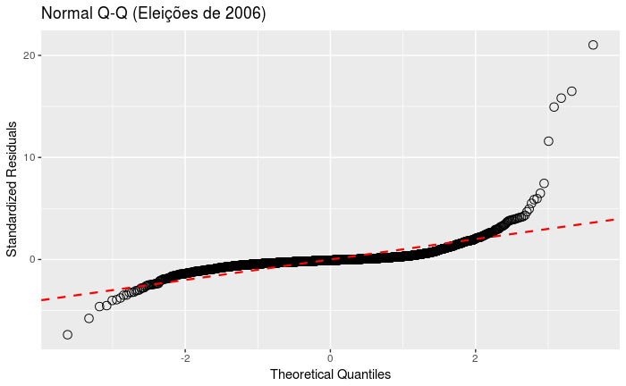

```r
fit_2006 %>%
  ggplot(aes(sample=rstandard(.))) +
  stat_qq(na.rm = TRUE, shape=1,size=3) +
  labs(title="Normal Q-Q (Eleições de 2006)",
  x="Theoretical Quantiles", y="Standardized Residuals") +
  geom_abline(color = "red", size = 0.8, linetype="dashed")
```

[figure not shown]

```r
fit_2010 %>%
  ggplot(aes(sample=rstandard(.))) +
  stat_qq(na.rm = TRUE, shape=1,size=3) +
  labs(title="Normal Q-Q (Eleições de 2006)",
  x="Theoretical Quantiles", y="Standardized Residuals") +
  geom_abline(color = "red", size = 0.8, linetype="dashed")
```

Nos dois gráficos Q-Q, os resíduos aparentam desviar um pouco da distribuição normal, pois eles possuem um certo desvio em relação a reta tracejada.

## No caso de haver variáveis pouco explicativas e/ou redudantes, construa um novo modelo sem essas variáveis e o compare ao modelo com todas as variáveis (e.g. em termos de R2 e RSE). Faça isso para 2006 e 2010 separadamente.

|  | r.squared | adj.r.squared | sigma | statistic | p.value | df | logLik | AIC | BIC | deviance | df.residual |
| --- | --- | --- | --- | --- | --- | --- | --- | --- | --- | --- | --- |
| 1 | 0.5738835 | 0.5448663 | 30678.87 | 19.77732 | 0 | 220 | -40260.24 | 80962.48 | 82319.88 | 3.026877e+12 | 3216 |

|  | r.squared | adj.r.squared | sigma | statistic | p.value | df | logLik | AIC | BIC | deviance | df.residual |
| --- | --- | --- | --- | --- | --- | --- | --- | --- | --- | --- | --- |
| 1 | 0.5378316 | 0.5105668 | 34670.48 | 19.72624 | 0 | 226 | -47848.95 | 96151.9 | 97582.91 | 4.584588e+12 | 3814 |

Tabela do modelo antes de remover variáveis redudantes:

|  | Modelo de 2006 | Modelo de 2010 |
| --- | --- | --- |
| R² | 0.5779 | 0.5405 |
| RSE | 30550 | 34590 |

Tabela do modelo depois de remover variáveis redudantes:

[output not shown]

Ao remover as variáveis redundantes e as váriáveis que não faziam sentido para o modelo, o R² e o RSE se manteve ligeiramente semelhante Isso mostra que o novo modelo sem essas variáveis é tão explicativo quanto quando estava com elas. Esta siatuação de se manter o mesmo R² ocorreu tanto em 2006 quanto em 2010, mostrando que mesmo com dados bem diferentes, a relação tende a se manter semelhante.

## Construa agora uma regressão considerando os anos 2006 e 2010 em conjunto. Que diferenças/semelhanças você percebe em relação aos modelos individuais por ano? Veja a questão 2 para sugestões que você usar para comparação.

```r
summary(fit_2006_2010)
```

```
Call:
lm(formula = votos ~ . - recursos_de_pessoas_fisicas - recursos_de_pessoas_juridicas -
    quantidade_fornecedores - quantidade_doacoes - total_receita,
    data = .)

Residuals:
    Min      1Q  Median      3Q     Max
-345818  -12051   -6579   -1395 1317628

Coefficients:
                                        Estimate Std. Error t value Pr(>|t|)
(Intercept)                            1.339e+04  6.112e+02  21.906  < 2e-16 ***
sequencial_candidato                  -3.917e-08  4.324e-09  -9.059  < 2e-16 ***
quantidade_doadores                    4.350e+01  5.093e+00   8.542  < 2e-16 ***
media_receita                          1.013e-01  4.706e-02   2.153   0.0314 *
recursos_de_outros_candidatos.comites -2.693e-02  4.926e-03  -5.467 4.73e-08 ***
recursos_proprios                     -5.213e-02  3.573e-03 -14.591  < 2e-16 ***
recursos_de_partido_politico          -4.603e-02  4.583e-03 -10.044  < 2e-16 ***
quantidade_despesas                   -1.515e+01  1.770e+00  -8.562  < 2e-16 ***
total_despesa                          1.028e-01  2.464e-03  41.724  < 2e-16 ***
media_despesa                         -1.706e-02  8.474e-02  -0.201   0.8405
---
Signif. codes:  0 ‘***’ 0.001 ‘**’ 0.01 ‘*’ 0.05 ‘.’ 0.1 ‘ ’ 1

Residual standard error: 36620 on 7466 degrees of freedom
Multiple R-squared:  0.4118,    Adjusted R-squared:  0.4111
F-statistic: 580.7 on 9 and 7466 DF,  p-value: < 2.2e-16
```

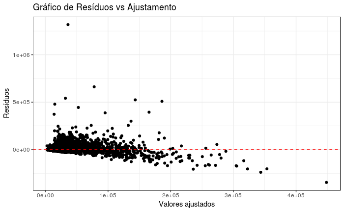

O padrão observado no plot de resíduos dos dados individualemente se manteve no plot dos dados em conjunto. Portanto, mesmo com o aumento nos dados o modelo não melhorou.

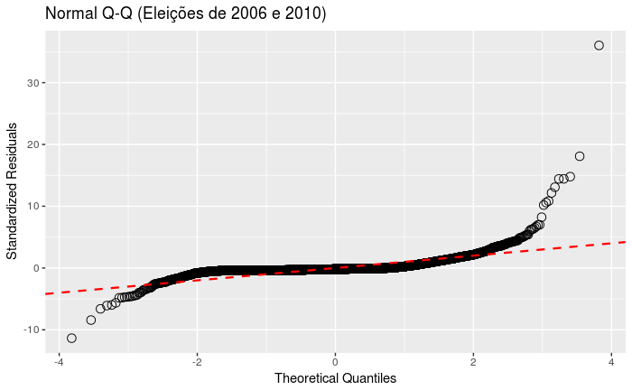

O Q-Q plot para os dados em conjunto é semelhando ao dos dados separados, ou seja, os resíduos aparentam desviar um pouco da distribuição normal, pois eles possuem um certo desvio em relação a reta tracejada. Portanto, o modelo com os dados de 2006 e 2010 não gerou uma melhora significatina no nosso modelo de regressão.